# Posit Assistant and Codex

Lecture 12a  
POLS 6394 · Tuesday, November 10

# This week in AI

## Every morning, lately

[figure not shown]

## Fable 5.2: a new frontier model

[figure not shown]

Anthropic released **Fable 5.2** this week. A team of 1,000 Fable agents **formalized Fermat’s Last Theorem** in 30 hours, rewriting the proof in a language a computer checks step by step. The same setup with Opus 5.5 got about a quarter of the way.

- A formal proof checks itself: the computer accepts every step or it doesn’t.
- Your reading for Thursday is Ethan Mollick’s first take on Fable 5.2.

[@claudeai](https://x.com/claudeai/status/2119867129751056485), November 9, 2026.

## The same intelligence keeps getting smaller

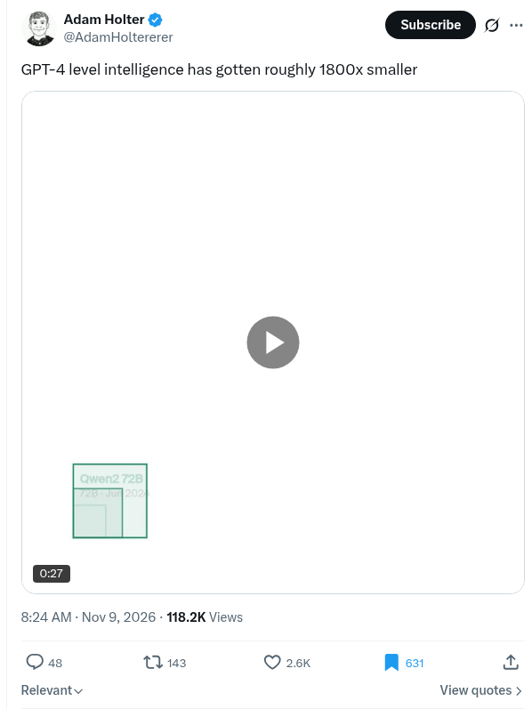

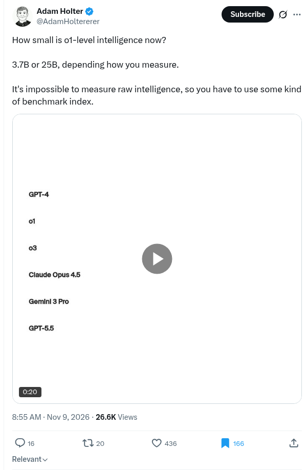

Adam Holter tracks how big a model must be to match an older frontier model’s benchmark scores.

- GPT-4-level scores now come from a model about **1,800 times smaller**.
- o1-level scores: **3.7 billion or 25 billion** parameters, depending on the benchmark index.

Last year’s frontier now fits on a laptop.

Adam Holter (@AdamHoltererer), [GPT-4 level](https://x.com/AdamHoltererer/status/2119798405656629562) and [o1 level](https://x.com/AdamHoltererer/status/2119806162392547435), November 9, 2026.

## More thinking isn’t always better

[figure not shown]

Models let you choose a **reasoning effort**: how long they think before answering. Holter plotted Fable 5.2’s benchmark scores against cost at each level.

- **Max** costs 2.3 to 6.6 times as much as **High**.
- On the coding benchmarks it scored about the same or lower. It gained only on a knowledge test.

Codex has the same setting. The default is fine for today; more effort costs more of your allowance and doesn’t buy a correct answer.

[@AdamHoltererer](https://x.com/AdamHoltererer/status/2119906845355565357), November 9, 2026, from Artificial Analysis and FrontierCode data.

## What a subscription is worth

Theo Browne (t3.gg) priced out what the big AI subscriptions would cost if you paid API rates for the same usage:

| Plan | Usage at API prices, per month |
| --- | --- |
| OpenAI, $200 | about $4,300 |
| OpenAI, $500 | about $10,500 |
| Anthropic, $200 | about $12,000 |

- Subscriptions are heavily subsidized. Your $20 ChatGPT Plus buys far more work in Codex, which we start today, than $20 of API credit would.
- Price per token isn’t the whole story. Some models use many more tokens to finish the same task, so compare the **cost per task**.
- API credit is for code that calls a model itself, like ellmer later in the course.

Theo Browne, [“OpenAI is getting desperate”](https://www.youtube.com/watch?v=Hq2c7pww1Ds&t=300s), YouTube, from 5:00.

## Do we still need to check?

[figure not shown]

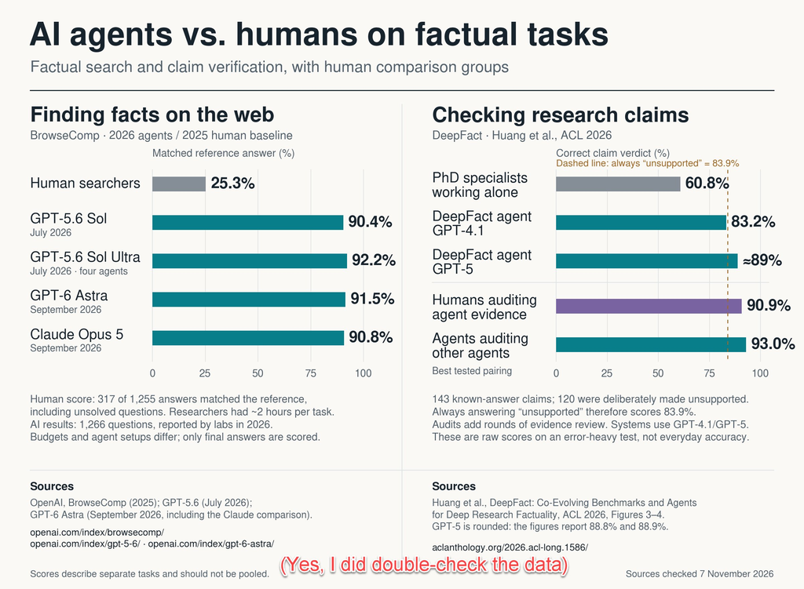

Mollick: on recent benchmarks, AI agents beat human experts, PhD specialists included, at finding facts and checking claims. **Discussion:** if he’s right, what’s left of our habit of checking?

[@emollick](https://x.com/emollick/status/2119140502746308674), November 7, 2026.

## Values are one fine-tune away

[figure not shown]

Back to Thursday’s China slide. Chinese open models are among the strongest, and they carry the Communist Party line in their weights.

- **Nous Research** built an 803-prompt eval across seven value categories, such as free expression, democracy and privacy, and measured how often a model adopts the Chinese Communist Party line.
- After fine-tuning a 27-billion-parameter Qwen model on about 53 million tokens, the rate fell from **22% to 1%**, with no loss on its general benchmark.

Their point cuts both ways: anyone can fine-tune values *out* of an open model, or *in*.

[@NousResearch](https://x.com/NousResearch/status/2118822925445050435), November 6, 2026. Eval, weights and data: nousresearch.com/arete.

## Last week’s election: the comparison decides the answer

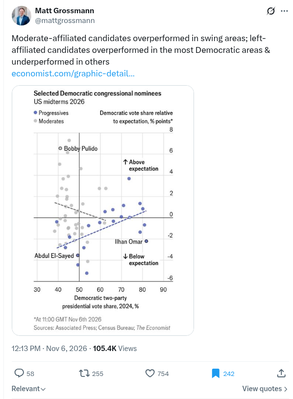

[figure not shown]

## Data centers were on the ballot

[figure not shown]

David Shor: voters sided **against data centers in 40 of 41** local ballot measures last week. The result barely tracked how Republican a county was: deep-red Ohio voted about the same as California.

The computing behind this course has a politics of its own: power, water, land and local tax deals. It’s a research topic for political scientists, too.

[@davidshor](https://x.com/davidshor/status/2118126319913640429), November 4, 2026.

# Today

## Today

We start with **Posit Assistant**, inside RStudio, one power at a time. Then the same habits move to **Codex**, an agent that works in your project from the terminal.

1. Posit Assistant: setup and five steps.
2. From assistant to agent: what changes when the tool can run commands and touch many files.
3. Getting there: a terminal review, then the practice folder and Codex.
4. How much it may do: sandbox and approval settings.
5. Git as the safety net: see every change, keep what you checked, undo one file.
6. Asking an agent: the job, and a fence around it.
7. Lab: four steps on a small practice repo, each with a check you do yourself.

# Meet Posit Assistant

## An assistant inside RStudio

**Posit Assistant** is an AI assistant for RStudio 2026.04 and later, installed from the RStudio toolbar. You chat with it in a pane next to your code.

Unlike web chat, it works on your actual project:

- It can read the files in your project; type `@` and a filename to point it at one.
- It knows which objects exist in your R session, by name and type. It doesn’t automatically get their **contents**: it sees values in console output and plots, or runs code to look.
- It can write code, run R code, and edit your files, asking first when an action is risky.

Today we turn those powers on one at a time, on code you already wrote by hand in Part I.

[RStudio User Guide: Posit Assistant](https://docs.posit.co/ide/user/ide/guide/tools/posit-ai.html) · [Posit Assistant documentation](https://assistant.posit.co/docs/getting-started/)

## Set it up

Skip any steps you finished on November 3.

1. Click **Posit Assistant** on the RStudio toolbar. The first time, click **Install Posit Assistant**.
2. When it asks, click **Trust this workspace**, so it can work in your course project.
3. Click **Configure provider**, choose **OpenAI**, and supply the API key you stored Tuesday.
4. **Switch the model to Terra** in the model picker, and keep it all class.

It bills your OpenAI API credit by the token. Your ChatGPT Plus subscription doesn’t cover it. The counter below the message box shows an estimate; glance at it now and then.

## Where you type

Type in the **message box at the bottom of the Posit Assistant pane**:

[figure not shown]

To ask a question, just type it. A message that starts with `/` is a **command**. Some switch the mode (`/ask`, `/restricted`); others do something (`/context`, `/report`). Send today’s mode commands on their own, then your request as a second message.

## Modes: how much it may do

| Mode | How you get there | It may |
| --- | --- | --- |
| **Normal** | Where every chat starts. `/normal` brings you back from Ask. | Read, run code, and edit files. Safe actions run without asking; risky ones ask first. |
| **Ask** | `/ask`, or pick **Ask** in the mode picker | Read files and search, see console history and plots. No R code runs and no files change. |
| **Restricted** | `/restricted` turns it on; send it again to turn it off | Asks before every action you haven’t already allowed, even reading a file. |

[Posit Assistant: Ask mode](https://assistant.posit.co/docs/features/ask-mode/) · [Permissions](https://assistant.posit.co/docs/features/permissions/)

## Ground rules for today

- **Never ask it about your API key.** RStudio blocks it from *reading* `.Renviron`, but code it runs could still print environment variables.
- **Approve actions *Once*.** Not *For this session* or *For this project*.
- **Don’t switch on `/yolo` or `/auto`.** They let it act without asking you.
- **Ask, read, check.** Every step below ends with a check you do yourself.

If the assistant won’t connect, follow my screen. The workbook has a sample answer for each step.

## Point it at the file: `@`

“Fix my code” leaves the assistant to guess which code. Point at it:

1. In the message box, type `@`. A menu of your project’s files opens.
2. Pick `12a-workbook.qmd`. The file’s contents go along with your message.
3. Then name the chunk by its label, such as `lab12a-reshape`.

Every prompt in today’s steps does this, so you’ll see `@12a-workbook.qmd` in each one. A file and a chunk label are precise; “the code above” isn’t.

[Posit Assistant: chat features](https://assistant.posit.co/docs/features/chat-features/)

## Read what it wants to do

When the assistant wants to run code or change a file, it stops and shows you the action first.

1. **Expand it.** Read the code it will run, or the file it will change.
2. **Ask yourself:** do I understand it? Does it touch only what I asked about?
3. **Click Once.**

| Choice | What it allows |
| --- | --- |
| **Once** | This one action. **Use this today.** |
| **For this session** | Every action like it, for the rest of this session |
| **For this project** | Every action like it in this project, from now on |

The broader choices save clicks and give up the moment where you read the action.

[Posit Assistant: permissions](https://assistant.posit.co/docs/features/permissions/)

## Five steps, one new power each

| Step | New power | Your check |
| --- | --- | --- |
| 1. Explain | Reads your code | Trace one row yourself |
| 2. Inspect | Runs code to look at data | Compare with your own count |
| 3. Fix | Diagnoses an error | You run the fix |
| 4. Write | Writes new code | Check columns and one value |
| 5. Edit | Changes your file | Read the diff, then render |

Each step has a prompt in the workbook. Paste it exactly, so we can compare answers.

## Step 1: explain code you wrote

The workbook’s first chunk is the Problem Set 1 reshape: democracy scores for 96 countries in 9 years, from wide to long.

Run the chunk. Then paste this question into Posit Assistant:

```
Explain what the chunk lab12a-reshape in @12a-workbook.qmd does,
line by line, in plain language. Don't change anything.
```

**Your check** is on the next slide.

## Step 1: your check

**1. Albania in 1992, both ways.** Run the workbook chunk `lab12a-albania`:

```r
dem_wide |> filter(country == "Albania") |> select(country, `1992`)
```

```
# A tibble: 1 × 2
  country `1992`
  <chr>    <dbl>
1 Albania      5
```

```r
dem_long |> filter(country == "Albania", year == 1992)
```

```
# A tibble: 1 × 3
  country  year democracy_score
  <chr>   <int>           <dbl>
1 Albania  1992               5
```

The first line finds Albania’s row in the wide table and keeps its `1992` column. The backticks are needed because the name starts with a number.

The second finds the one Albania–1992 row in the long table. Both should say **5**.

**2. The row count.** The reshape chunk ends with `nrow(dem_long)`. It should print **864**: 96 countries × 9 year columns.

**3. Compare.** Did the explanation say each country-year becomes one row, and that `year` comes from the old column names?

## Step 2: let it look at the data

Run the workbook chunk that loads `cigarettes`. The assistant knows the object exists and its type, but not what’s inside.

Send `/restricted` on its own, so it asks before each action you haven’t already allowed. (If you switched to Ask mode, send `/normal` first.) Then paste:

```
How many states and how many years are in the cigarettes data
frame in my R session? Run code to find out, and show me the code.
```

When it asks to run code, read the code, then click **Once**.

**Your check:** compare its answer with `n_distinct(cigarettes$state)` and `n_distinct(cigarettes$year)`, which you run yourself.

## Step 3: diagnose an error

The workbook’s next chunk has a mistake. Run it and copy the error, which ends:

```
! object 'packs' not found
```

Paste the prompt, adding the exact error:

```
This chunk in @12a-workbook.qmd (lab12a-broken) should compute
average packs per capita by year. It fails with the error below.
Explain the cause and propose the SMALLEST fix. Don't edit the file.

<paste the error>
```

**Your check:** make the fix yourself and run it. “Smallest fix” and “don’t edit” keep it from rewriting more than you asked.

## Step 4: write new code

A weak request leaves the model guessing:

```
Plot cigarette prices.
```

A strong request states the **goal**, the **context**, the **constraints** and the **output** you want:

```
Goal: a line chart of the average REAL price of cigarettes by year.
Context: the cigarettes data frame in my session; avgprs is the price
in cents and cpi is the consumer price index.
Constraints: ggplot2 only; don't change the data.
Output: one complete R chunk and one sentence on how you adjusted
for inflation.
```

**Your check:** paste its code into the workbook chunk and run it. Does it use `avgprs`, not `tax`? Does it divide by `cpi`? Compute 1995 yourself: about 120 (1982–84 cents).

## A wrong answer to step 4

Suppose the assistant had answered step 4 with this. It **runs without error**:

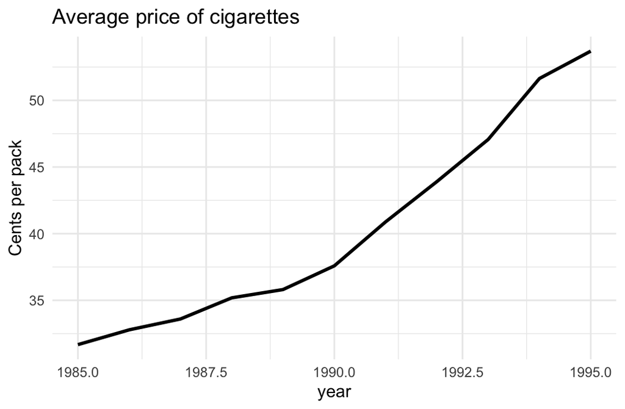

```r
library(tidyverse)
cigarettes <- read_csv("Data/cigarettes/cigarette.csv",
                       show_col_types = FALSE) |>
  select(-rownames)

cigarettes |>
  group_by(year) |>
  summarize(avg = mean(tax)) |>
  ggplot(aes(x = year, y = avg)) +
  geom_line(linewidth = 1) +
  labs(title = "Average price of cigarettes",
       y = "Cents per pack") +
  theme_minimal()
```

It runs, but it isn’t right and it isn’t what you asked. It plots the excise **tax**, not the price, and never adjusts for inflation. In 1995 the average tax (state, federal and local combined) was about 54 cents a pack; the average price was about $1.83.

## The checked version, and a title to check

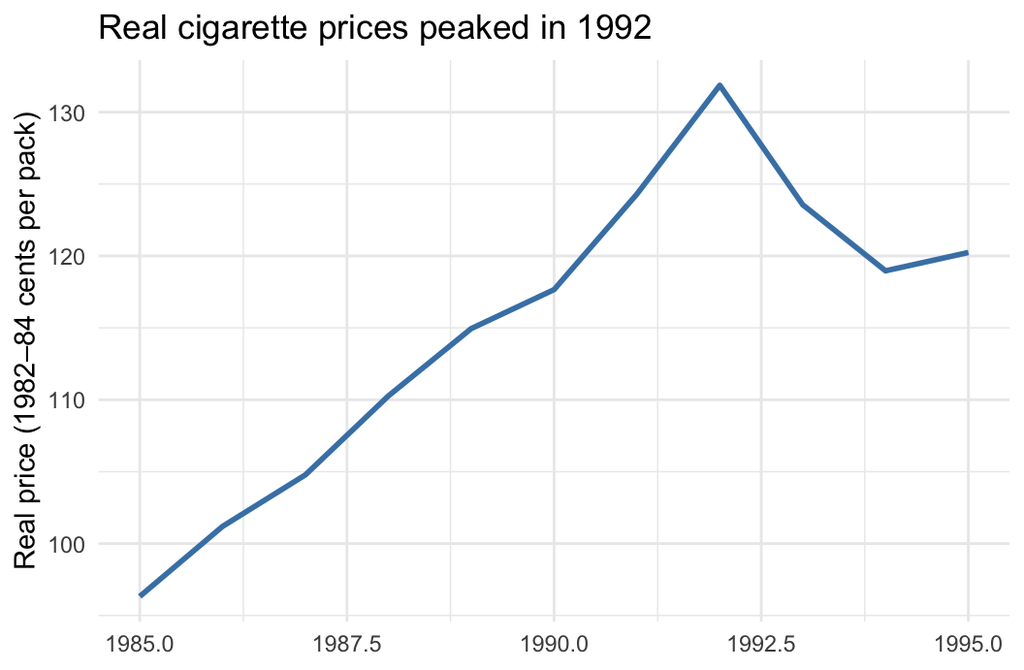

```r
cigarettes |>
  group_by(year) |>
  summarize(real_price = mean(avgprs / cpi)) |>
  ggplot(aes(x = year, y = real_price)) +
  geom_line(linewidth = 1, color = "steelblue") +
  labs(
    title = "Real cigarette prices peaked in 1992",
    x = NULL,
    y = "Real price (1982–84 cents per pack)"
  ) +
  theme_minimal()
```

An earlier draft of this slide was titled “Real cigarette prices rose steadily from 1985 to 1995.” The arithmetic was right, but the title wasn’t: prices rose to about 132 in 1992 and then fell to about 120. Check the words as well as the code.

## Step 5: let it edit your file

So far you copied code in yourself. Now the assistant edits the workbook directly.

1. **Commit first** in the Git pane, so you can see and undo every change.
2. Paste:

```
In @12a-workbook.qmd, in the chunk lab12a-real-price, add a title
that states what the chart shows. Change nothing else in the file.
```

3. Approve the edit **Once**.

**Your check:** open the diff in the Git pane. Did it change only that chunk? Is the title true of the chart? Then render.

## What you just practiced

- In step 1 it only explained; by step 5 it was editing your file. You approved each action that changed something.
- Each step ended with an answer you already knew or could find yourself: Albania’s score, a count, the 1995 price, the diff.
- The strong prompt in step 4 named the columns. Saying that `avgprs` is a price and `tax` is a tax kept the model from guessing.

## A conversation fills up

Each message you send carries the conversation so far. Long chats get slower and costlier, and eventually older messages are **summarized**: they stay in the history, but the model no longer sees them word for word.

- `/context` shows what’s taking up room in the current chat. Clicking the token counter gives a fuller breakdown.
- Starting a fresh chat for a new task is cheap and keeps old detours out of the way.
- The cost shown is an **estimate** of your OpenAI API bill. That’s separate from Codex, which runs on your ChatGPT Plus allowance.

[Posit Assistant: context management](https://assistant.posit.co/docs/features/context-management/)

## History is not undo

Conversations save automatically. You can rename them, reopen them, and edit an earlier message, which starts a new branch of the chat.

None of that puts your **files** or your R session back the way they were. For files, the safety net is the one you used in step 5: **commit first, read the diff after**.

[Posit Assistant: conversations](https://assistant.posit.co/docs/features/conversations/)

## Three shortcuts worth knowing

| Type | What happens |
| --- | --- |
| `/report` | Writes a Quarto document from the conversation. You can add instructions: `/report Keep the checked real-price code and explain the cpi adjustment` |
| `/context` | Shows what fills the current chat |
| `!r nrow(cigarettes)` | Runs that R line directly, without the model, and adds its output to the chat |

A `/report` document is a draft built from the chat, not a check of the code in it. Read and render it before you keep it.

[Posit Assistant: commands](https://assistant.posit.co/docs/features/commands/)

## Coming Thursday: instructions that persist

Every prompt today repeated the same facts: which file, which columns, don’t change the data. A project can say them once.

- An `AGENTS.md` file in the project’s main folder holds standing instructions, such as “the raw data is in `Data/`; never change it.” Posit Assistant reads it in trusted projects, and so does Codex.
- `/plan` asks for a written plan before any code. It doesn’t lock the assistant out of editing the way Ask mode does, so read the plan before you say go.

We write an `AGENTS.md` in 12b.

[Posit Assistant: memory](https://assistant.posit.co/docs/features/memory/) · [Plan mode](https://assistant.posit.co/docs/features/plan-mode/)

## Problem Set 6: last week’s votes

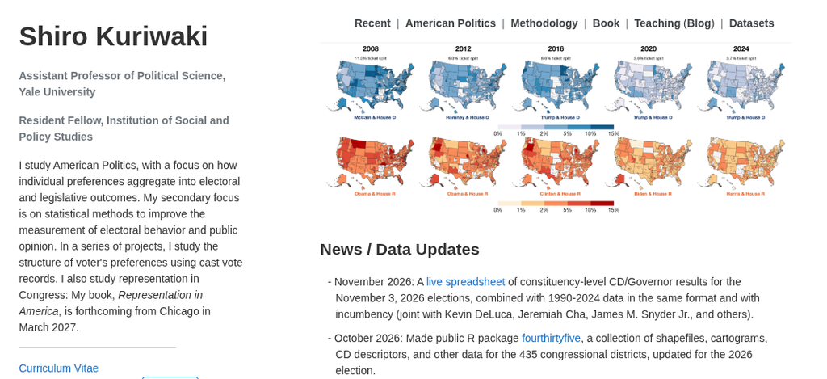

**How much did House districts swing toward Democrats between 2024 and 2026?** Posit Assistant works with Shiro Kuriwaki’s live spreadsheet of the results; you check it and write a short memo. Released today in `Psets/pset-06/`, due **Tuesday, November 17 at 10:00 AM**.

[shirokuriwaki.com](https://www.shirokuriwaki.com/) · Cha, DeLuca, Kuriwaki & Snyder, [Candidates in American General Elections, 2026 version](https://docs.google.com/spreadsheets/d/1otML47xPsa9Wf1A_XEISLJFHEm6wpv5D3FzRe2-xZXY/edit)

# From assistant to agent

## Same habits, a bigger tool

|  | Posit Assistant | Codex |
| --- | --- | --- |
| Where it runs | A pane in RStudio | A terminal app, in your project |
| What it sees | Your project and R session | Your repository’s files |
| What it can do | Write, run R code, edit files | Run shell commands, edit and create many files |
| How you check | A check per step | The same, plus Git |

Underneath is the same kind of model. What differs is the **harness** around it: which tools it has and what it’s allowed to do.

## The agent loop

[figure not shown]

You’re no longer copying code between a chat and RStudio. That saves time, and it means changes can pile up before you look.

## What changes when it can act

- It reads the **real** files: actual column names, actual paths, the actual error.
- It can run commands, read their output, and try again without you.
- It can change several files in one turn, including ones you didn’t mention.

So **give it the limits you’d give a new research assistant, then check its work.**

## Assistant or agent?

| Job | Better fit | Why |
| --- | --- | --- |
| Explain a chunk, fix one error | Posit Assistant | It sees your R session and the file you’re in |
| Plot an object you already loaded | Posit Assistant | It knows your objects by name |
| Rename a column across five scripts | Codex | One change, many files |
| Write a new script, or set up folders | Codex | It creates files; Git shows every one |
| A task you couldn’t check yourself | Neither, yet | Learn it first: that was Part I |

Both use the same kinds of model. Pick the one whose reach matches the job, and no more.

# Getting there

## Terminal review: where am I?

Codex lives in the terminal, so first a quick review. Open **Ghostty** on a Mac, or **Git Bash in Windows Terminal** on Windows.

```bash
pwd          # print working directory: the folder you're in
ls           # list what's in it
ls -l        # list it long: one line per item, with details
ls -a        # list everything, including hidden items like .git
```

In `ls -l`, a line starting with `d` is a folder; the number before the date is the size in bytes; the name is at the end. Options can be combined: `ls -la`.

## Moving around

```bash
course              # the shortcut setup made: go to your course repository
cd Labs/w12         # go into a folder, relative to where you are
cd ..               # up one level, to the parent folder
cd -                # back to the folder you were just in
cd ~                # your home folder
```

- **Tab** finishes a file or folder name for you. Type `cd La` and press Tab.
- A name with spaces needs quotes: `cd "My Project"`.
- **Up arrow** brings back your last command. `clear` clears the screen.

## `z`: let the terminal remember

`zoxide`, installed in 11a, learns the folders you visit. After you’ve been to `Labs/w12/sandbox` once, `z sandbox` jumps there from anywhere.

It has to be switched on once. In the terminal:

```bash
course                          # go to your course repository
bash 12a-terminal-setup.sh      # run the setup script for today
```

`bash` runs the script, which adds two lines to your shell’s settings file: one turns on `z`, the other turns on **mcfly**, so **Ctrl-R** searches the commands you’ve typed before. It keeps a backup of the file first. Then close the terminal and open a new one.

`z` only knows folders you’ve visited: `cd` there once first.

## Look before you open

```bash
head -3 data/turnout.csv    # the first 3 lines of a file
wc -l data/turnout.csv      # count its lines
cat NOTES.md                # print a whole (short) file
```

These only read. Codex runs the same kinds of commands to look around your project. When it shows you one, you’ll know what it does.

**Your turn, 2 minutes.** Type `course`, then `cd Labs/w12/sandbox`. Run `pwd` and `ls -l`. How many lines does `data/turnout.csv` have, and what are its columns?

## Open the practice folder in your terminal

Today’s practice repo is `Labs/w12/sandbox`: made-up teaching data, 2020 turnout for 12 states, messy on purpose.

In the terminal:

```bash
course
cd Labs/w12/sandbox
git status
```

- `git status` lists the branch, changed files, and **untracked** (new) files. You should be on `main`. If it shows earlier uncommitted work, commit it first in your usual way; don’t throw it away.

## Start Codex, read-only

```bash
codex --sandbox read-only --ask-for-approval on-request
```

- `--sandbox read-only` stops ordinary file writes.
- `--ask-for-approval on-request` lets Codex ask your permission when it needs a restricted action. It doesn’t promise to ask before every command.

The first time, choose **Sign in with ChatGPT**. Codex may ask whether to trust the folder; that trust covers your **whole** course repository, not just `sandbox`. That’s why every prompt today names the files it may use.

Type `/status` to see the current settings. Type `/quit` to leave.

## `/status`: your settings and your allowance

Type `/status` inside Codex. It shows:

- the model, the folder it’s working in, and the **permissions** in effect. Check these match how you launched it.
- your **5-hour limit** and **weekly limit**: the share left in each window and when it resets.

These are your ChatGPT Plus allowance for Codex, not your OpenAI API dollars, which pay for Posit Assistant. Long, sprawling sessions use the allowance fastest; small scoped tasks use less and are easier to check.

## Stopping it mid-turn

While Codex works, the bottom of the screen says **esc to interrupt**.

- Press **Esc** to stop the current turn. Codex stays open, and you can say what you want instead.
- Stopping doesn’t undo anything it already changed. Run `git status` to see what it did before you stopped it.
- `Ctrl+C` also stops a turn; pressed at an empty prompt, it quits Codex.

Stop early when it heads somewhere you didn’t ask: the wrong file, a long detour, a command you don’t understand.

# How much it may do

## Changing permissions mid-session

Type `/permissions` to open a picker. On our version (0.162.0) it offers:

| Choice | For this course |
| --- | --- |
| **Read Only** | Steps 1 and 2 |
| **Ask for approval** | Steps 3 and 4: edits in the workspace; asks for more |
| **Approve for me** | No: an automatic reviewer approves for you |
| **Full Access** | No |

Use the picker, then check with `/status`. Typing extra words after `/permissions` doesn’t change anything; Codex treats them as a message. In this course, restarting with new flags is the simplest reliable way.

# Git is the safety net

## See every change

```bash
git status          # every changed file, and every NEW file
git diff            # line-by-line changes to files Git already tracks
```

- `git diff` doesn’t show what’s inside a **new** file. `git status` lists it; open it yourself.
- RStudio’s Git pane shows both: `M` for modified, `?` for new.

More files changed than you asked for? Stop and read before anything else.

## Read the list before the lines

Start with *which* files changed, then read the lines:

```bash
git status --short     # one line per changed or new file
git diff --stat        # how many lines changed in each tracked file
```

A made-up example of what `git status --short` might show after Step 4:

```
 M R/02-summary.R
 M data/turnout.csv
?? R/clean.R
```

`M` means modified, `??` means new and untracked. Here the raw data changed, and nothing you asked for touched it. That’s the finding: stop and look before you read a single line of `R/clean.R`.

## What you’re reading for

Not whether the code is elegant. Three questions:

- Did it change **only** what you scoped?
- Does each changed line do what it said it would?
- Did it quietly swap a column, add a package, or “improve” something you didn’t ask about?

Codex ends each turn with a summary of what it did. The summary is a claim; the diff is the evidence.

## Inside Codex: `/diff` and `/review`

| Command | What it does | What it isn’t |
| --- | --- | --- |
| `/diff` | Shows Git’s changes without leaving Codex, including new files | Anything new: it’s the same evidence as `git status` and `git diff` |
| `/review` | Asks a model to review changes for problems | A check. It’s another model’s opinion |

`/diff` is a convenience. `/review` can catch something you missed, but its “looks good” is a claim like any other. Your own check still decides.

## Keep only what you checked

Stage the files you mean to keep, **by name**:

```bash
git add R/02-summary.R R/clean.R data/turnout_clean.csv NOTES.md
git diff --cached          # the staged changes, new files included
git commit -m "Complete supervised Codex exercise"
git push
```

- `git add` with filenames stages just those files for the next commit.
- `git diff --cached` shows exactly what the commit will contain. Read it first.
- Then the usual commit and push. There’s no pull request.

Quit Codex before typing Git commands, so you don’t send them to Codex as a prompt.

## Undo one file, not everything

```bash
git restore -- R/02-summary.R   # discard this file's unstaged changes
```

- Use it **before** you stage the file, and only on the file you mean. It puts the file back to its last staged or committed version.
- It doesn’t remove a **new** file. To drop one, delete that specific file in the Files pane.
- Avoid whole-project resets such as `git checkout -- .` or `git reset --hard`: they also discard work you meant to keep.

# Asking an agent

## An agent prompt says two things

- **The job:** what to make or change.
- **The fence:** which files it may touch, and what it must not do.

The fence is what keeps the change small enough to check. Every prompt in today’s four steps has both.

## A vague ask and a scoped one

```
Clean up the turnout data.
```

Which file? Overwrite the raw CSV or write a new one? Percent or fraction? Keep the blank turnout or drop the row? The agent will choose, and you’ll find out from the diff.

```
Create R/clean.R. It must read data/turnout.csv and, when I run it,
write data/turnout_clean.csv. Keep all 12 rows and all five columns.
Make turnout a numeric fraction (0.604, not 60.4), with the blank as NA.
...
```

Every choice you’d care about is made in the prompt, so the check is short: 12 rows, five columns, Texas at 0.604.

## Small steps beat one big ask

```
BIG:    Build the whole turnout analysis and make the figures.

SMALL:  Create R/clean.R only. Don't run it. I'll check it before
        the next step.
```

- A big ask gives a big diff, and a big diff gets skimmed. That’s how a quiet error gets in.
- A small step gives a diff you can actually read.
- If you can’t check the result in about two minutes, the step was too big.

## Delegation: one agent, several helpers

Codex can hand parts of a job to **subagents**: helper agents that each do one piece and report back.

- Give each one a **single, bounded task**, and say which files it may read or change.
- A lighter model can do routine checks; a stronger one does the harder reasoning.
- Helpers inherit the main session’s permissions. Saying “read-only” in a prompt doesn’t add a sandbox.
- Helpers use your allowance too. Running in parallel is faster, not cheaper.

The main agent supervises its helpers the way you supervise it: it checks their work before reporting to you. And you still check the final result.

[Codex: subagents](https://learn.chatgpt.com/docs/agent-configuration/subagents)

## A delegation prompt

For after Step 4, once `R/clean.R` exists. It’s the second extension in the workbook.

```
Split this check between two subagents, both read-only. One checks that
every path and column name in R/clean.R exists in data/turnout.csv.
The other recomputes Texas's turnout fraction from the raw file and
compares it with R/clean.R's logic. Use a lighter model for both if one
is available. Check their findings yourself, then report: what each
found, and whether they agree. Don't edit files, commit, or push.
```

- Two independent jobs, neither changing a file, so the helpers can’t collide.
- One check has a **known answer** (Texas, 0.604), so you can test the report.
- Model names and availability vary by plan. If it can’t pick a lighter model, the main model does the work.

# Four steps

## Four steps, one new power each

| Step | Codex | Sandbox | Your check |
| --- | --- | --- | --- |
| 1. Explain | Reads named files | `read-only` | Open the files yourself |
| 2. Propose a command | Proposes; runs only when you say | `read-only` | Compare with the Files pane |
| 3. Fix | Edits one line | `workspace-write` | `git diff`, then you run it |
| 4. Create | Writes a new script | `workspace-write` | You read it, run it, count |

Codex never runs the R scripts today; you do. The exact prompts are in the workbook.

## Step 1: explain without changing anything

```
Read only README.md, NOTES.md, R/01-load.R, R/02-summary.R, and
data/turnout.csv in this folder. Explain each file, identify the data
columns and row unit, and point out the error in R/02-summary.R. Don't
edit files, run the R scripts, or search outside this folder.
```

**Your check:** open the files yourself. There are 12 rows, one per state, and five columns. `turnout` is text like `"60.4%"`, one turnout is blank, two registrations are `N/A`, and `02-summary.R` groups by `regon`, which doesn’t exist. Did Codex say all of that, and nothing that isn’t there?

## Step 2: decide whether a command should run

```
Propose one read-only command that lists the filenames in the R folder.
Use a basic command for this computer's shell, not Python or R code.
Show the command and explain it, then stop. Don't run it or edit any
files until I say so.
```

Read the command. Do you understand it, and does it only read? Then reply:

```
Run that command once. Don't edit files.
```

**Your check:** the output should match the `R` folder in RStudio’s Files pane: `01-load.R` and `02-summary.R`. On Windows, Codex may use PowerShell even though you started in Git Bash; read the command it actually proposes.

## Step 3: make one small edit

Run `R/02-summary.R` yourself first (the workbook has the chunk) and read the error. Then `/quit` and restart Codex so it can edit:

```bash
codex --sandbox workspace-write --ask-for-approval on-request
```

```
Fix the misspelled grouping column in R/02-summary.R. Change only regon
to region; leave every other line and file unchanged. Explain why the old
line failed. Don't run the script; I'll run it myself.
```

**Your check:** in a second terminal tab, `git diff -- R/02-summary.R` should show one change, `regon` to `region`. Then run the script yourself. The tibble prints rounded means: Midwest 0.707, West 0.700, South 0.678, Northeast 0.67.

## Step 4: create a script, then run it yourself

```
Create R/clean.R. It must read data/turnout.csv and, when I run it, write
data/turnout_clean.csv. Keep all 12 rows and all five columns. Make
turnout a numeric fraction (0.604, not 60.4), with the blank as NA; make
registered numeric, with both N/A entries as NA; trim state names and use
title case. Preserve region and year. You may create only R/clean.R now.
Don't run it, change existing files, create the CSV yourself, commit, or
push. Explain what the script will do.
```

**Your check:** read `R/clean.R` before running it. Then run it and count: 12 rows, numeric `turnout` and `registered`, 1 missing turnout, 2 missing registrations, Texas 0.604, “California” title-cased, and the raw CSV unchanged.

## Problems to check for

Three kinds of problem to look for:

- **Invented paths or columns:** it describes a file before it exists, or a column that isn’t there.
- **“It works,” without running it:** it reports success it never checked.
- **Extra changes:** you asked for one file; it also “tidied” two others.

None of them announces itself. Reading what changed and running the check yourself catches them. Thursday’s class practices exactly this.

## Your turn: a task from your own project

*About 3 minutes, with a neighbor.*

Think of one small, real task from your project that you’d hand to Codex.

1. **The job:** what should it make or change?
2. **The fence:** which files may it touch? Which must it leave alone?
3. **Your check:** what would you look at, in about two minutes, to know it worked?

If the check takes longer than that, split the task. Keep your answer: Thursday and the project session the week of November 16 build on it.

# Lab

## Lab: the four steps

*~35 minutes.* Work the four steps in order in `Labs/w12/sandbox`.

For each step, the workbook asks for three things: what Codex said it did, the check you ran, and what the check showed. Finish by staging the four named files, reading `git diff --cached`, and committing.

Amanda and I are circulating. If something is stuck, say so out loud.

## Before Next Class

- Render the workbook, commit it with your sandbox work, and push. There’s no pull request.
- **Problem Set 6**, released today: Posit Assistant analyzes last week’s House results and you check it. It’s in `Psets/pset-06/pset-06.qmd`, due **Tuesday, November 17 at 10:00 AM**.
- **Read for Thursday:** Ethan Mollick, [“Fable 5.2 and Jagged AGI”](https://www.oneusefulthing.org/p/fable-52-and-jagged-agi), *One Useful Thing*, November 9. Come with one place where you think the jaggedness would bite in your own research.
- In `Labs/w12/sandbox/NOTES.md`, write one thing Codex got wrong, or one check that showed it was right.
- **Thursday (12b): steering agents.** Project instructions in an `AGENTS.md` file, planning before editing, and a drill in testing the agent’s claims, whether they turn out right or wrong. Same practice folder.